# Using Data Science to Make a Christmas Playlist that Doesn’t Suck

Brad Stieber

November 22, 2018

In this post, I’m going to use data from Spotify to make a Christmas playlist that you might actually like. We’re going to employ a few standard data science techniques to **import** data, **explore** it, and finally **model** the data.

Here are the steps we’re going to take

1. Pull data into `R` using the [**`spotifyr`**](https://www.rcharlie.com/spotifyr/) package
2. Clean up the data using functions from the [**`caret`**](http://caret.r-forge.r-project.org/) package
3. Use principal components analysis to reduce the dimensionality of our data
4. Apply random forest, k-nearest neighbor, and logistic regression modeling techniques to find Christmas songs that don’t suck
5. Use our findings to create a playlist that you won’t feel like turning off after ten minutes

Here are the packages we’ll need:

```r
library(spotifyr)
library(tidyverse)
library(scales)
library(caret)
library(ggrepel)
theme_set(theme_bw())
```

## Getting data from Spotify

The `spotifyr` package makes it really easy to grab data from Spotify. You can find a pretty good tutorial to get up-and-running from the [package’s website](https://www.rcharlie.com/spotifyr/).

In the code below, we’re going to connect to Spotify, and then pull all of my playlists. I created two playlists for this analysis. The first is called **holiday_playlist**, and it’s a collection of 22 songs that I thought were pretty good. Then, we’re going to pull in another playlist called **spotify_holiday_playlists**, which is a collection of 300+ holiday songs coming from a variety of Spotify holiday playlists (you can find the list of playlists I used [on my GitHub](https://github.com/bgstieber/files_for_blog/blob/master/make-christmas-playlist/spotify_playlists.txt)).

```r
# connect
access_token <- get_spotify_access_token()
```

```r
# get my playlists
my_playlists <- get_user_playlists('12102534356')
# get playlist and playlist track info
## my curated list
holiday_playlist <- my_playlists  %>%
  filter(playlist_name == 'holiday_playlist') %>%
  get_playlist_tracks()

holiday_playlist_features <- holiday_playlist %>%
  get_track_audio_features()

## collection of spotify songs
spotify_holiday <- my_playlists %>%
  filter(playlist_name == 'spotify_holiday_playlists') %>%
  get_playlist_tracks() %>%
  # filter duplicates
  filter(!duplicated(.[c('track_name', 'artist_name')] %>%
           mutate_all(toupper)))

spotify_holiday_features <- spotify_holiday %>%
  get_track_audio_features()
```

Now we have all the data we’ll need for this analysis. We have four `data_frame`s to play with. There are two containing qualitative information about the tracks (`holiday_playlist` and `spotify_holiday`) and two containing quantitative information (`holiday_playlist_features` and `spotify_holiday_features)`.

The quantitative information has variables like **energy** (a measure of the intensity and activity of the track) and **danceability** (describes how suitable a track is for dancing). More information can be found in [the documentation for the Spotify API](https://developer.spotify.com/documentation/web-api/reference/tracks/get-audio-features/).

## Data Processing

Let’s take a look at the structure of `holiday_playlist_features`.

```r
str(holiday_playlist_features)
```

```
## 'data.frame':    22 obs. of  15 variables:
##  $ danceability    : num  0.653 0.737 0.589 0.721 0.634 0.328 0.355 0.691 0.347 0.446 ...
##  $ energy          : num  0.354 0.635 0.13 0.408 0.332 0.607 0.668 0.402 0.772 0.65 ...
##  $ key             : chr  "G" "G" "F" "D" ...
##  $ loudness        : num  -11.15 -8.14 -19.41 -9.77 -9.39 ...
##  $ mode            : chr  "minor" "major" "minor" "major" ...
##  $ speechiness     : num  0.0291 0.0321 0.0523 0.038 0.044 0.0315 0.0482 0.0599 0.0464 0.0331 ...
##  $ acousticness    : num  0.0488 0.812 0.824 0.899 0.807 0.319 0.362 0.703 0.388 0.787 ...
##  $ instrumentalness: num  7.98e-01 1.55e-06 6.08e-06 3.78e-01 4.19e-05 0.00 1.23e-06 0.00 0.00 1.34e-03 ...
##  $ liveness        : num  0.183 0.0532 0.107 0.104 0.159 0.765 0.727 0.463 0.1 0.0537 ...
##  $ valence         : num  0.128 0.855 0.211 0.675 0.655 0.395 0.413 0.844 0.46 0.815 ...
##  $ tempo           : num  88.2 120.1 66.1 110.6 116.9 ...
##  $ track_uri       : chr  "5k4RDTxRX1Wr4nNNjwTT59" "3NWriGPDUHUhZSbtDj2rMd" "6NBEjaO6uf9ZCxjylkazqh" "73bFwwGixozIc8w1zlI8Xv" ...
##  $ duration_ms     : num  206549 229827 215467 165134 159298 ...
##  $ time_signature  : num  4 4 4 4 4 3 4 4 4 4 ...
##  $ key_mode        : chr  "G minor" "G major" "F minor" "D major" ...
```

We can also visualize the quantitative variables. We’ll look at both data sets, and the distributions should give us insight into whether we need to transform any of the variables (e.g. log-scale, square root transformations).

First, we’ll look at the features from the playlist I hand-curated.

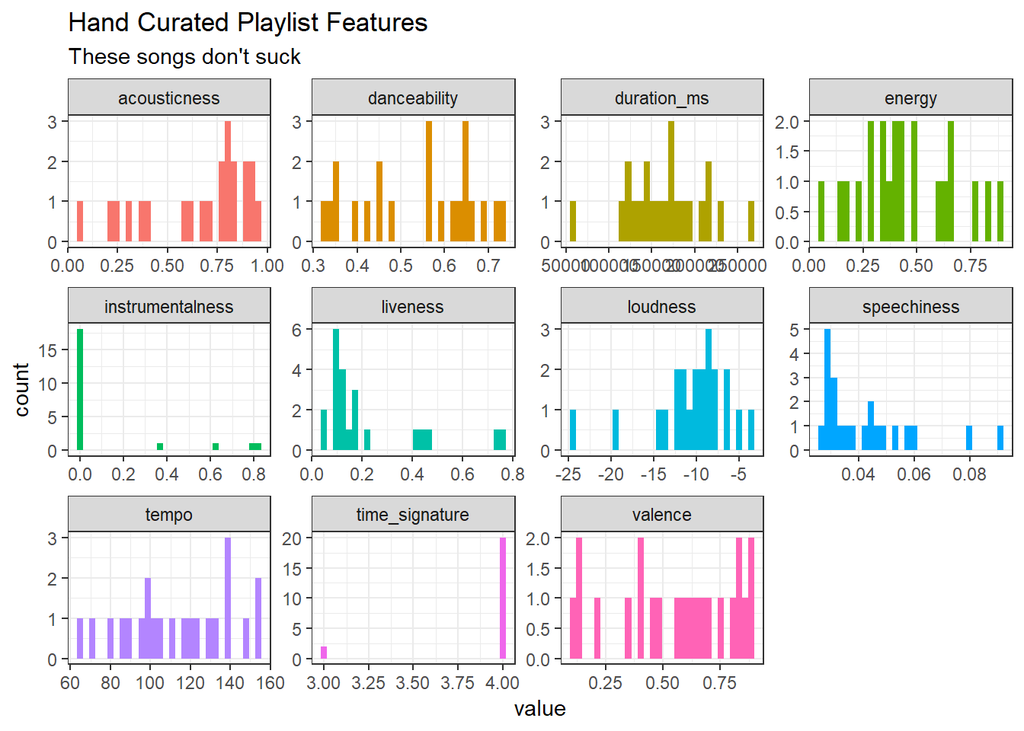

Then we’ll look at the playlist with candidate songs to be added to the Playlist that Doesn’t Suck.

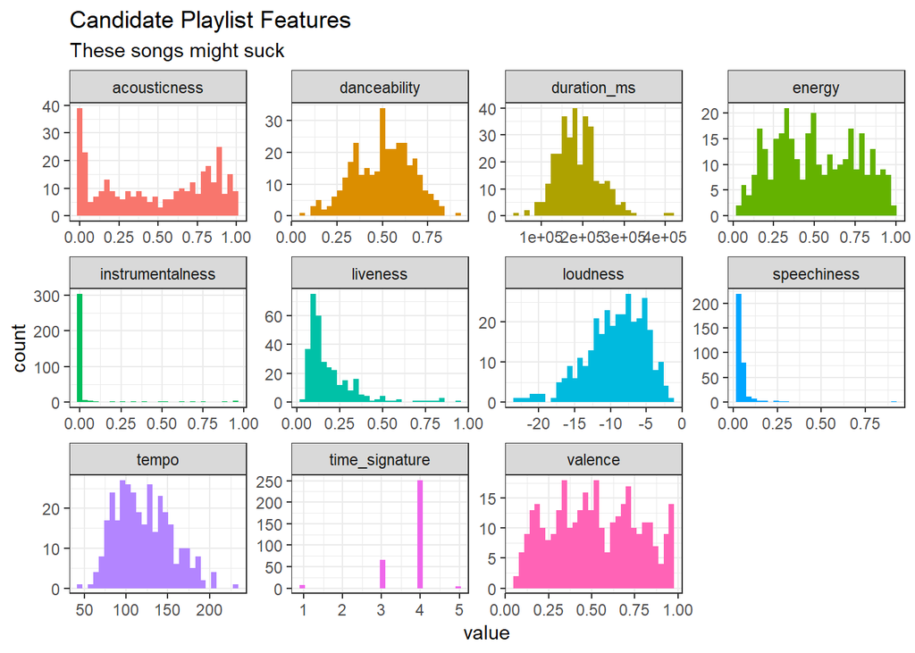

From the histograms above, we can make a few decisions about what we want to do with the quantitative variables:

1. Get rid of variables that seem quite discrete in nature (instrumentalness, speechiness, and time_signature)
2. Log-scale a few variables with right-skewed distributions (duration_ms, liveness, and tempo)
3. Center and scale variables to have mean zero and unit variance (this will make our PCA results more reasonable)

```r
vars_to_keep <- c("track_uri", "danceability", "energy",
                  "loudness", "acousticness", "liveness",
                  "valence", "tempo", "duration_ms")

vars_to_log1p <- c('duration_ms', 'liveness', 'tempo')

holiday_playlist_features2 <- holiday_playlist_features %>%
  select(vars_to_keep) %>%
  mutate_at(vars_to_log1p, log1p)

spotify_holiday_features2 <- spotify_holiday_features %>%
  select(vars_to_keep) %>%
  mutate_at(vars_to_log1p, log1p)

# center and scale, using my playlist as "training" set
pre_proc <- preProcess(holiday_playlist_features2,
                       method = c('center', 'scale'))

holiday_playlist_features2_scaled <- predict(pre_proc,
                                             holiday_playlist_features2)

spotify_holiday_features2_scaled <- predict(pre_proc,
                                            spotify_holiday_features2)
```

Let’s make the same histograms as above, but with the centered and scaled values.

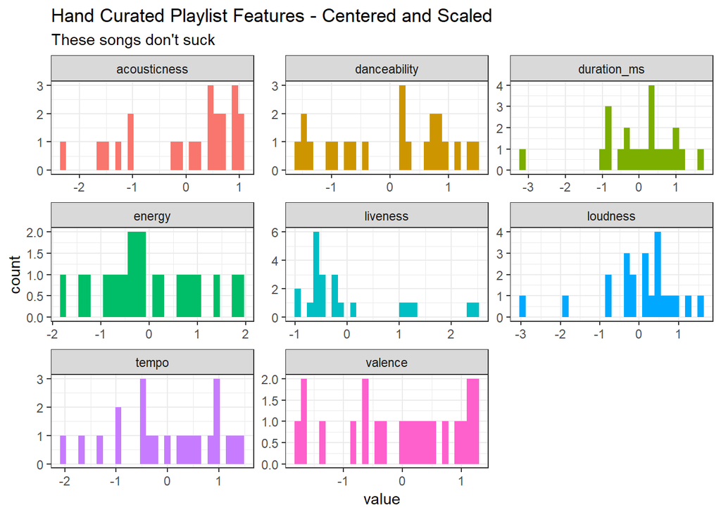

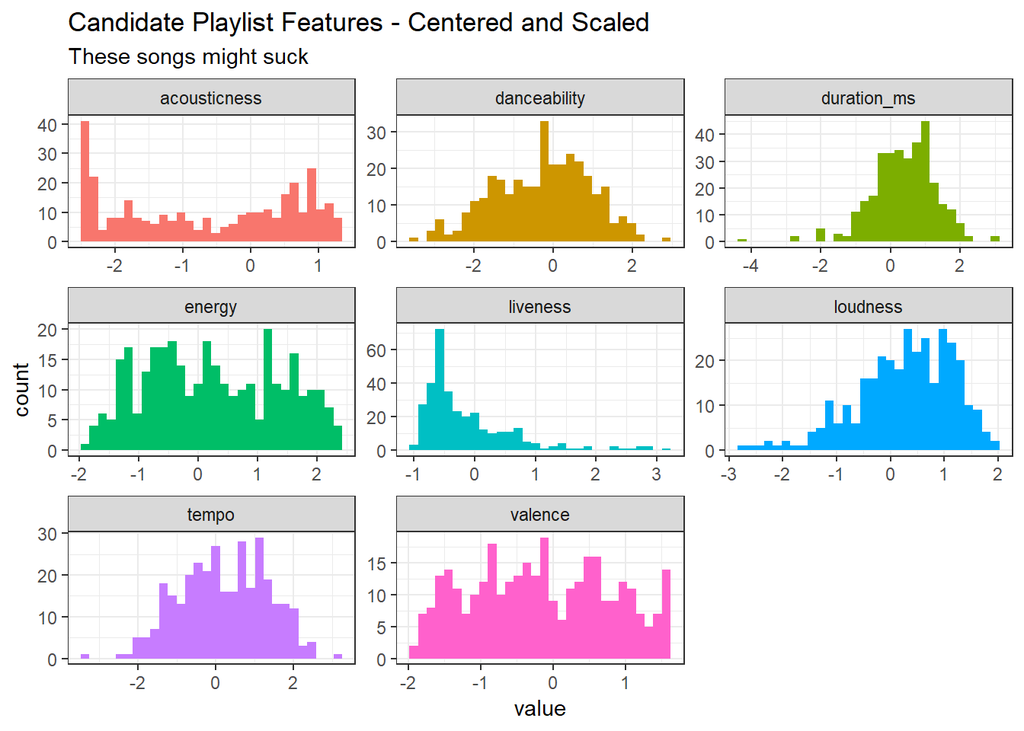

## Dimensionality Reduction with PCA

We have 8 quantitative variables in the data set, which makes it challenging to visualize. We can use a [dimensionality reduction](https://en.wikipedia.org/wiki/Dimensionality_reduction) technique like principal components analysis to make our data easier to visualize.

Performing PCA in `R` is fairly straightforward. We’re going to first run PCA on my curated playlist, and use the results to generate “predictions” for the larger playlist.

```r
# fit principal components (dimensionality reduction) on playlist
prco_holiday <- prcomp(holiday_playlist_features2_scaled[,-1])

pc_rotation <- prco_holiday$rotation %>%
  as_data_frame() %>%
  mutate(variable = row.names(prco_holiday$rotation))

training_pca <- predict(prco_holiday,
                        newdata = holiday_playlist_features2_scaled) %>%
  as_data_frame() %>%
  mutate(type = 'training') %>%
  bind_cols(holiday_playlist_features2_scaled)

testing_pca <- predict(prco_holiday,
                       newdata = spotify_holiday_features2_scaled) %>%
  as_data_frame() %>%
  mutate(type = 'testing') %>%
  bind_cols(spotify_holiday_features2_scaled)

full_pca <- training_pca %>%
  bind_rows(testing_pca)
```

And now we can visualize the first two principal components, and look for clusters in the data.

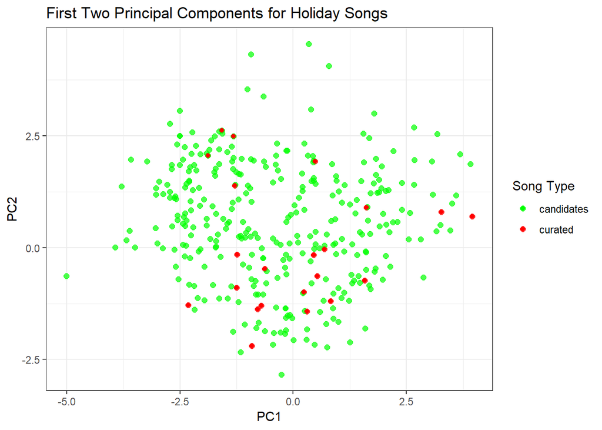

We can see that a majority of the songs from my holiday playlist have values for PC2 below zero (63.6%). Let’s look at the variable loadings for the first two principal components. These loadings describe the weights that are multiplied by the variables to calculate the respective principal components.

| variable | PC1 | PC2 |
| --- | --- | --- |
| duration_ms | 0.114 | 0.393 |
| liveness | -0.285 | 0.292 |
| energy | -0.557 | 0.149 |
| loudness | -0.500 | -0.010 |
| tempo | -0.224 | -0.281 |
| acousticness | 0.360 | -0.451 |
| danceability | -0.039 | -0.466 |
| valence | -0.404 | -0.489 |

There are three variables which have positive loadings for PC2 (duration_ms, liveness, and energy). The largest positive weight is for duration_ms, implying I am a Grinch that I tend to prefer shorter holiday songs.

There are five dots toward the top of the plot, which are separated from the rest of the data points. These are all coming from the candidate playlist, and it’s very likely that the methods from the **Models** section will exclude these songs from the final playlist.

```r
full_pca %>%
    top_n(5, PC2) %>%
    inner_join(spotify_holiday) %>%
    select(type, track_name, artist_name)
```

Five outlier songs from PC1 vs. PC2 plot

| type | track_name | artist_name |
| --- | --- | --- |
| testing | 2000 Miles - 2007 Remastered Version | Pretenders |
| testing | Christmas Lights - Live From Spotify London | Coldplay |
| testing | No Christmas While I’m Talking | The Walkmen |
| testing | O Holy Night | Go Radio |
| testing | Ave Maria | Neal Schon |

## Models

Our main purpose for building models is **to find songs that are similar to the ones in my curated playlist**. We’re going to tackle this using a collection of models.

We’re going to build three types of models: a logistic regression using the first four principal components, a random forest model on the full data, and a nearest neighbors search to find minimum distances.

For the first two models (logistic regression and random forest), we need to generate a binary variable to predict. In this setting, we can check whether the song belongs to my curated playlist or not. The end result of these models is a predicted probability, so songs with high predicted probabilities “look like” songs that are in my curated playlist.

```r
library(randomForest)
library(RANN)
X_logit <- full_pca %>% select(PC1:PC4)
X_rf <- full_pca %>% select(danceability:duration_ms)
y <- as.numeric(full_pca$type == 'training')
y_rf <- factor(y)

rand_f <- randomForest(y ~ .,
                       data = bind_cols(X_rf, 'y' = y_rf),
                       ntree = 5000)

rand_f_scores <- full_pca %>%
  filter(type == 'testing') %>%
  mutate(score = predict(rand_f, newdata = ., type = 'prob')[,2]) %>%
  select(track_uri, 'rand_f_score' = score)

logit <- glm(y ~ ., data = bind_cols(X_logit, 'y' = y), family = 'binomial')

logit_scores <- full_pca %>%
  filter(type == 'testing') %>%
  broom::augment(logit, newdata = ., type.predict = 'response') %>%
  select(track_uri, 'logit_score' = .fitted)

nn_k1 <- nn2(holiday_playlist_features2_scaled[,-1],
             spotify_holiday_features2_scaled[,-1],
             k = 1)

nn_scores <- spotify_holiday_features2_scaled %>%
  select(track_uri) %>%
  mutate(knn_score = nn_k1$nn.dists[,1]) %>%
  # need to reverse the "score", as it is a measure of distance
  mutate(knn_score = max(knn_score) - knn_score)
```

You’ll notice in that last line that I’m essentially reversing the distance “score” that comes from the k-nearest neighbors model. Since the output is a measure of distance, we actually want to have the lower scores get more weight. A lower distance means the song was closest to its nearest neighbor than a high distance.

## Combining our Intelligence

I want a playlist that can last on shuffle for around four hours (a decent length of time for a holiday party). Assuming an average song lasts 4 minutes, we’ll need about 60 songs in our final playlist. So, we need to find an additional 38 (give or take) songs to add.

We can pool the results of our models together to come up with a “score” to evaluate how well a certain song might fit in to my curated playlist.

```r
score_df <- rand_f_scores %>%
  full_join(logit_scores) %>%
  full_join(nn_scores) %>%
  mutate_if(is.numeric, scale) %>%
  mutate(avg_score = (knn_score + logit_score + rand_f_score) / 3)
```

In the code above, we gathered all three scores together, and utilized a naive [ensemble model](https://searchbusinessanalytics.techtarget.com/definition/Ensemble-modeling) to pool the results of the three models. We normalized the three scores before ensembling because the scores might all have different distributions, meaning the score with the highest variation would contribute too much to the overall score. Normalizing allows us to equally weight each of the three scores.

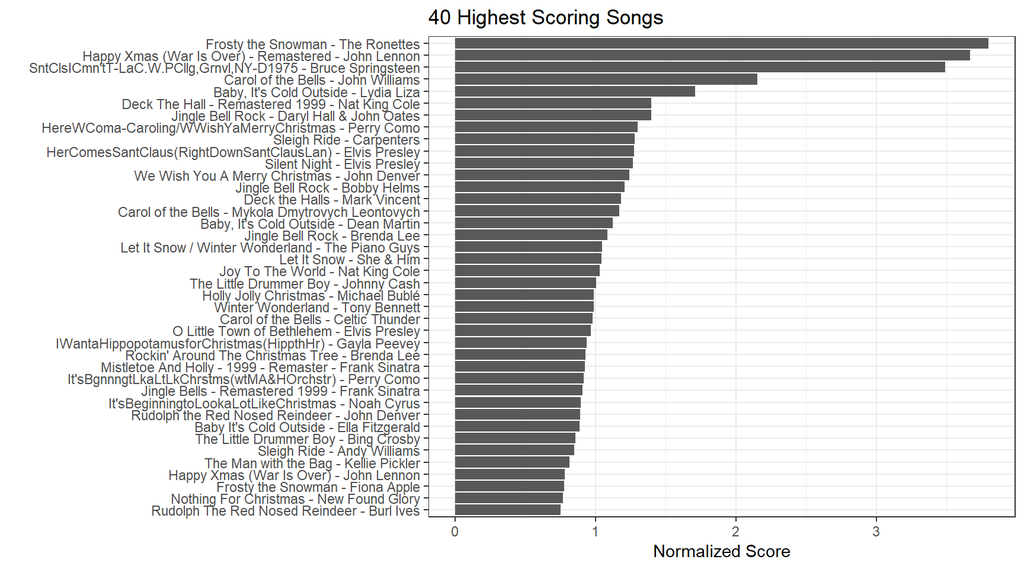